# HultPrize2018: Electric Power Loss & Covariates

C. McClintock

Spring 2018

## Objective

> Explore trends related to global electricity theft to better understand energy consumption and correlated variables to pitch a scalable, sustainable social enterprise to bring energy to 10 million people currently living in energy poverty.

## Background

Electricity theft, also called non-technical line loss, costs the energy utility industry $96 billion per year, most of that concentrated in emerging markets. [1](https://www.prnewswire.com/news-releases/96-billion-is-lost-every-year-to-electricity-theft-300453411.html) Of the total theft detected, 80% comes from residential buildings and 20% from commercial and industrial premises. 2 Hook lines are the most common used method of electricity theft, with 80% of global power theft is by direct tapping from the main power line. [3](http://file.scirp.org/Html/1-1770179_70365.htm) Theft of electricity causes significant harm to the economy, including include loss of revenue and profit of electricity providers and decrease of the stability and reliability of electrical power grids, as in some countries theft may range up to 40% of the total electricity distributed. [4](https://www.atlantis-press.com/journals/ijcis/25872435) India alone loses $16.2 billion per year, and plans to invest $21.6 billion between 2015 and 2025 to develop a smart grid to prevent fraud and theft. 5

## Data Origin

Data accessed through the [World Bank Open Data Portal](https://data.worldbank.org).

- Data Sets:
  - [Population, total](https://data.worldbank.org/indicator/SP.POP.TOTL)
  - [GDP (current US$)](https://data.worldbank.org/indicator/NY.GDP.MKTP.CD)
  - [Access to electricity (% of population)](https://data.worldbank.org/indicator/EG.ELC.ACCS.ZS)
  - [Electric power consumption (kWh per capita)](https://data.worldbank.org/indicator/EG.USE.ELEC.KH.PC)
  - [Electric power transmission and distribution losses (% of output)](https://data.worldbank.org/indicator/EG.ELC.LOSS.ZS)
  - [Children out of school, female (% of female primary school age)](https://data.worldbank.org/indicator/SE.PRM.UNER.FE.ZS?view=chart)

## Exploratory Data Analysis

### Highest percent losses

| Country | Electric power transmission and distribution losses (% of output) |
| --- | --- |
| Togo | 72.53521 |
| Libya | 69.69601 |
| Haiti | 60.11617 |
| Iraq | 50.63157 |
| Congo, Rep. | 44.54023 |
| Namibia | 36.24833 |
| Venezuela, RB | 36.04500 |
| Honduras | 34.94650 |
| Nepal | 32.20964 |
| Niger | 26.81159 |

### Lowest kWh per capita

| Country | Electric power consumption (kWh per capita) |
| --- | --- |
| Haiti | 38.96915 |
| South Sudan | 39.89256 |
| Niger | 51.44082 |
| Ethiopia | 69.71577 |
| Tanzania | 99.16747 |
| Benin | 100.22639 |
| Congo, Dem. Rep. | 108.58233 |
| Nepal | 139.14368 |
| Nigeria | 144.47992 |
| Togo | 152.72001 |

### Average Power Loss by Income Group

| Income Group | Average electric power transmission and distribution losses (% of output) |
| --- | --- |
| Low income | 26.039978 |
| Lower middle income | 15.964095 |
| Upper middle income | 15.991444 |
| High income | 6.588818 |

### GDP per Capita vs. kWh per Capita

First, economic development, measured by GDP per capita and energy use, measured by kWh per capita, are highly correlated in a basic linear model. Interestingly, Iceland has the highest kWh per capita, twice as high as the next country, and will be excluded from the models for clarity.

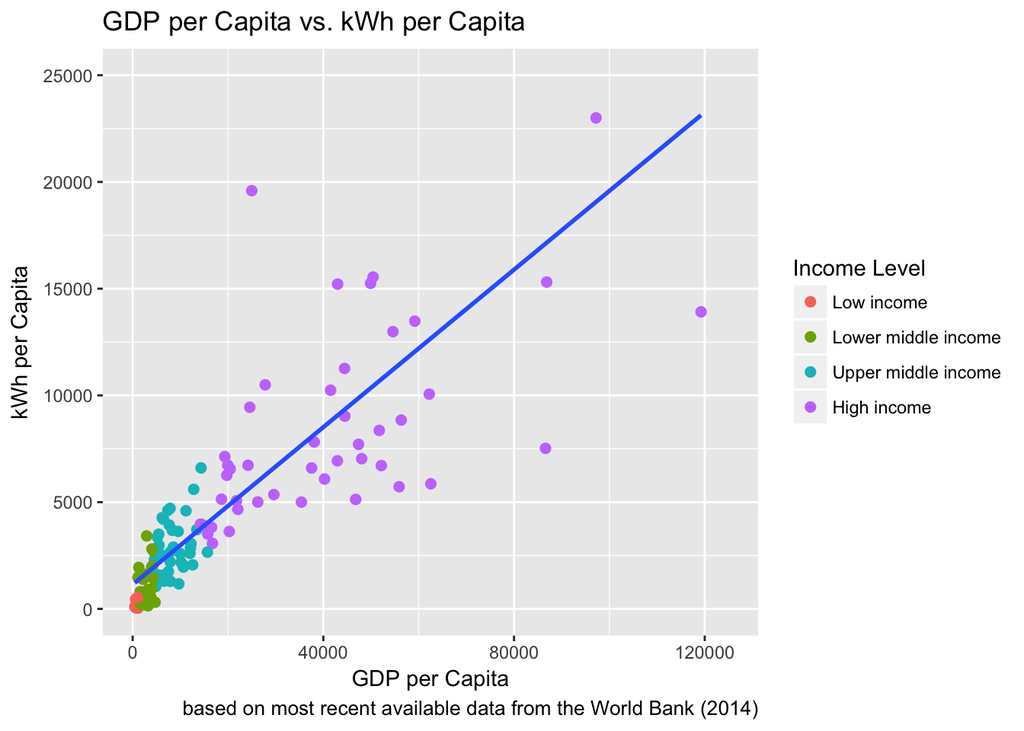

### GDP per Capita vs. Transmission & Distribution Loss (% of output)

Next, looking at electric power distribution and transmission loss as a function of GDP per capita. As expected, the highest output losses occur in the lowest income countries.

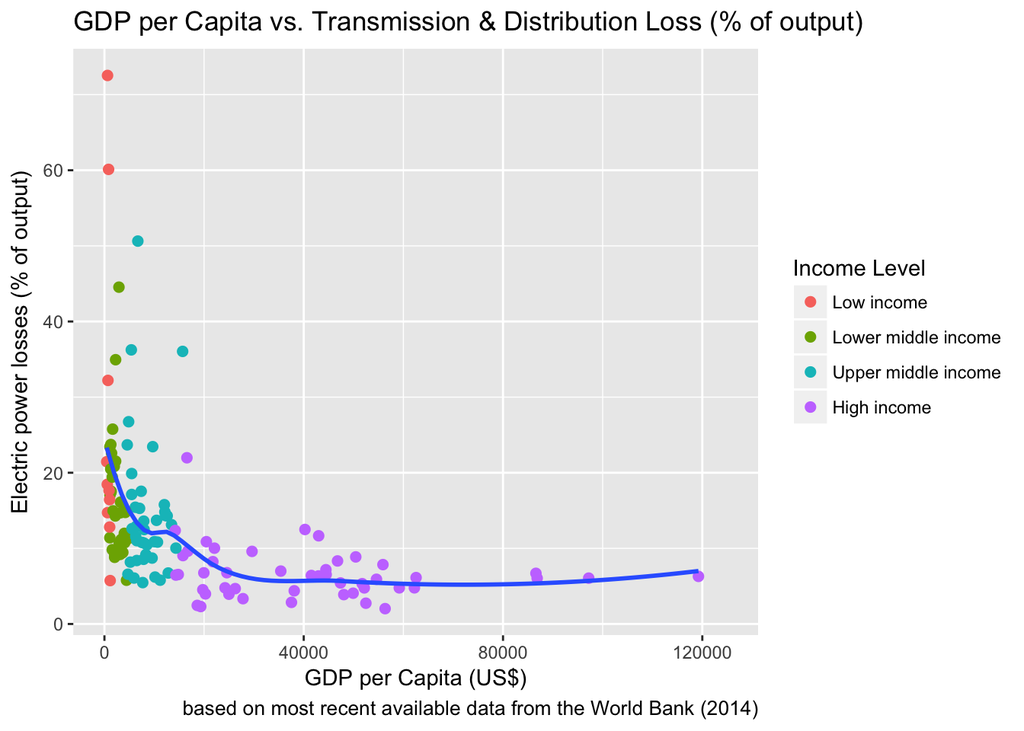

### kWh per Capita vs. Transmission & Distribution Loss (% of output)

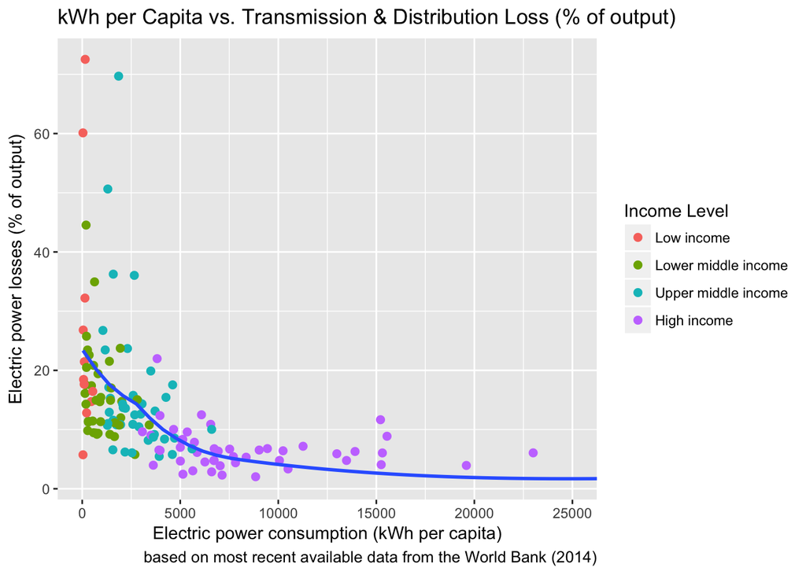

### Percent Access to Electricity vs. kWh per Capita

This is the most interesting trend discovered. Power consumption in kWh per capita does not rise substantially until a country has 100% electrification, and upper middle or high income levels.

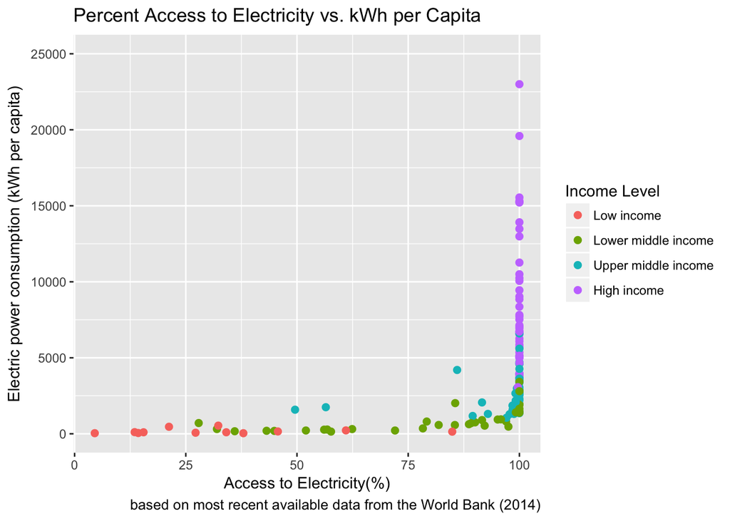

## Conclusion

Causation cannot be drawn from correlation, but the results are informative. Total electric power consumption only substantially increases when 100% of the population can be connected to the grid. There is substantial space in the market for investment in theft-resistant technologies.